# Prediction of Heart Disease

**GOAL** : To predict whether a person has heart disease or not.

**OUTCOME:**

I built two models(linear regression and random forest). The linear regression model performed better with the following metrics:

```
* Accuracy - 0.773

*roc_auc - 0.874
```

## INTRODUCTION

This datset contains 76 attributes, but all published experiments refer to using a subset of 14 of them. In particular, the database is the only one that has been used by ML researchers to this date. The "goal" field refers to the presecnce of heart disease in the patient.

**Content**

Attribute information :

1. Age
2. Sex
3. chest pain type (4 values)
4. resting blood pressure
5. serum cholestoral in mg/dg
6. fasting blood sugar > 120mg/dl
7. resting electrocardiographic results (vaLUES 0,1,2)
8. maximum heart rate achieved
9. exercise induced angina
10. oldpeak = ST depression induced by exercise relative to test
11. the slope of the peak exercise ST segment
12. number of major vessels (0-3) colored by flourosopy
13. thal: 3 = normal ; 6 = fixed defect; 7 = reversable defect

## PLAN

1. Clean the data
2. Visuaize the data
3. Build a prediction model(random forest and linear regression)
4. Evaluate the model.

## Load in the dataset.

```r
heart <- read.csv("C:/Users/USER/Desktop/heart disease/heart.csv", stringsAsFactors = FALSE)
```

Load in the libraries.

```r
library(tidyverse)
library(tidymodels)
library(corrplot)
library(ggcorrplot)
library(vip)
```

Let us have a quick look at the dataset.

```r
skimr::skim(heart)
```

Data summary

| Name | heart |
| --- | --- |
| Number of rows | 303 |
| Number of columns | 14 |
| _______________________ |  |
| Column type frequency: |  |
| numeric | 14 |
| ________________________ |  |
| Group variables | None |

**Variable type: numeric**

| skim_variable | n_missing | complete_rate | mean | sd | p0 | p25 | p50 | p75 | p100 | hist |
| --- | --- | --- | --- | --- | --- | --- | --- | --- | --- | --- |
| ï..age | 0 | 1 | 54.37 | 9.08 | 29 | 47.5 | 55.0 | 61.0 | 77.0 | ▁▆▇▇▁ |
| sex | 0 | 1 | 0.68 | 0.47 | 0 | 0.0 | 1.0 | 1.0 | 1.0 | ▃▁▁▁▇ |
| cp | 0 | 1 | 0.97 | 1.03 | 0 | 0.0 | 1.0 | 2.0 | 3.0 | ▇▃▁▅▁ |
| trestbps | 0 | 1 | 131.62 | 17.54 | 94 | 120.0 | 130.0 | 140.0 | 200.0 | ▃▇▅▁▁ |
| chol | 0 | 1 | 246.26 | 51.83 | 126 | 211.0 | 240.0 | 274.5 | 564.0 | ▃▇▂▁▁ |
| fbs | 0 | 1 | 0.15 | 0.36 | 0 | 0.0 | 0.0 | 0.0 | 1.0 | ▇▁▁▁▂ |
| restecg | 0 | 1 | 0.53 | 0.53 | 0 | 0.0 | 1.0 | 1.0 | 2.0 | ▇▁▇▁▁ |
| thalach | 0 | 1 | 149.65 | 22.91 | 71 | 133.5 | 153.0 | 166.0 | 202.0 | ▁▂▅▇▂ |
| exang | 0 | 1 | 0.33 | 0.47 | 0 | 0.0 | 0.0 | 1.0 | 1.0 | ▇▁▁▁▃ |
| oldpeak | 0 | 1 | 1.04 | 1.16 | 0 | 0.0 | 0.8 | 1.6 | 6.2 | ▇▂▁▁▁ |
| slope | 0 | 1 | 1.40 | 0.62 | 0 | 1.0 | 1.0 | 2.0 | 2.0 | ▁▁▇▁▇ |
| ca | 0 | 1 | 0.73 | 1.02 | 0 | 0.0 | 0.0 | 1.0 | 4.0 | ▇▃▂▁▁ |
| thal | 0 | 1 | 2.31 | 0.61 | 0 | 2.0 | 2.0 | 3.0 | 3.0 | ▁▁▁▇▆ |
| target | 0 | 1 | 0.54 | 0.50 | 0 | 0.0 | 1.0 | 1.0 | 1.0 | ▇▁▁▁▇ |

## DATA CLEANING

Checking for any missing values.

```r
Missing_Indices <- sapply(heart, function(x)sum(is.na(x)))
Missing_Values <- data.frame(Name=names(heart), Indices=Missing_Indices)
Missing_Values[Missing_Values$Indices>0,]
```

| Name | Indices |
| --- | --- |

Let us rename the age column.

```r
colnames(heart)[1] <- "age"
```

There are no missing values.

## DATA TRANSFORATION

Most values in the data are either o or 1. 1 for positive response and o for negative response. We will rename them.

```r
heart_clean <- heart %>%
  mutate(target = ifelse(target == 1 , "Yes", "No"),
         sex = ifelse(sex == 1 , "Male", "Female"),
         fbs = ifelse(fbs == 1 , ">125", "<125"),
         exang = ifelse(exang == 1 , "Yes", "No"),
         cp = case_when(cp == 1 ~ "ATYPICAL ANGINA",
                        cp == 2 ~ "NON-ANGINAL PAIN",
                        cp == 3 ~ "ASYMPTOMATIC",
                        cp == 0 ~ "None"),
         restecg = ifelse(restecg == 0, "NORMAL", "ABMORMALITY"),
         slope = as.factor(slope),
         ca = as.factor(ca)) %>%
 mutate_if(is.character, as.factor)

colnames(heart_clean)[1] <- "age"
```

## DATA EXPLORATION

**What percantage of people have a heart disease?**

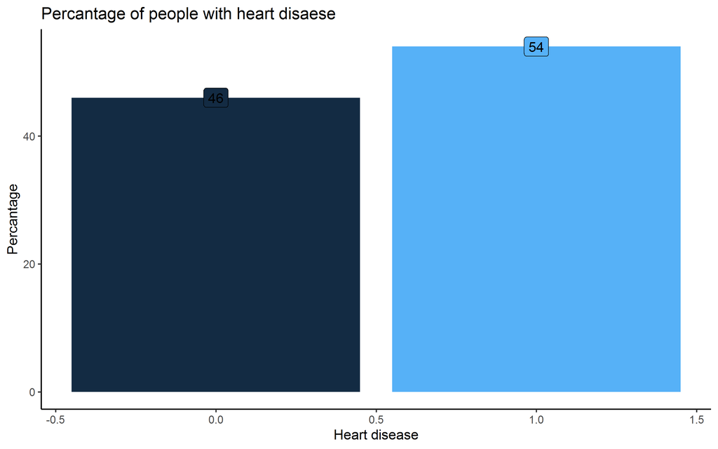

```r
heart %>%
  count(target) %>%
  mutate(pct =round( n / sum(n) * 100),2) %>%
  ggplot(aes(target, pct, fill = target)) +
  geom_col( show.legend = FALSE) +
  geom_label(aes(label = pct)) +
  theme_classic() +
  theme(legend.position = "none") +
  labs(title = "Percantage of people with heart disaese",
       y = "Percantage",
       x = "Heart disease")
```

There are 54% percent with heart disase while 46% without.

** What is the distribution of heart disease across age?**

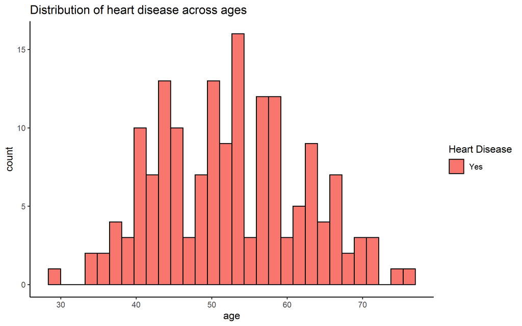

```r
heart_clean %>%
  filter(target == "Yes") %>%
  ggplot(aes(age, fill = target)) +
  geom_histogram(color = "black") +
  theme_classic() +
  guides(fill = guide_legend(title = "Heart Disease")) +
  ggtitle("Distribution of heart disease across ages")
```

It is more common btwn 40-60 years.

** What is the distribution of age across gender?**

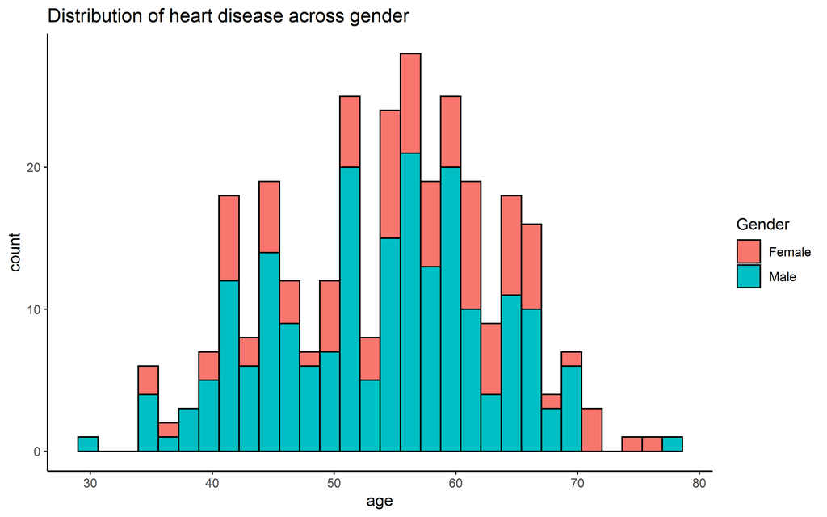

```r
heart_clean %>%
  ggplot(aes(age, fill = sex)) +
  geom_histogram(color = "black") +
  theme_classic() +
  guides(fill = guide_legend(title = "Gender")) +
  ggtitle("Distribution of heart disease across gender")
```

Males are the majority.

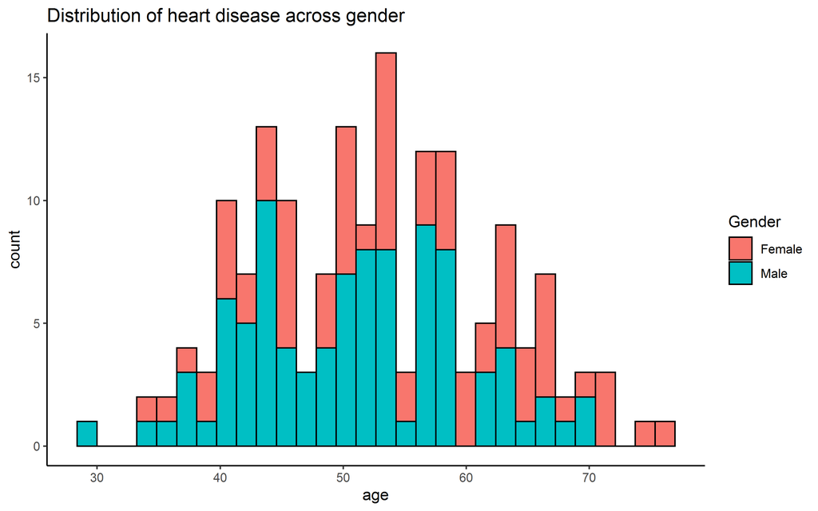

```r
heart_clean %>%
  filter(target == "Yes") %>%
  ggplot(aes(age, fill = sex)) +
  geom_histogram(color = "black") +
  theme_classic() +
  guides(fill = guide_legend(title = "Gender")) +
  ggtitle("Distribution of heart disease across gender")
```

**What is the count of gender with heart disease?**

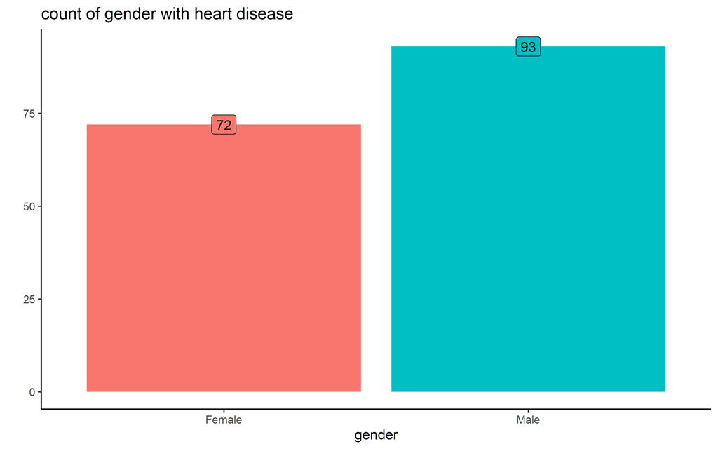

```r
heart_clean %>%
  filter(target == "Yes") %>%
  count(sex) %>%
  ggplot(aes(sex, n, fill = sex)) +
  geom_col(show.legend = F) +
  theme_classic() +
  geom_label(aes(label = n)) +
  theme(legend.position = "none") +
  labs(title = "count of gender with heart disease",
       y = "",
       x = "gender")
```

**Levels of cholosterol in the genders across the ages**

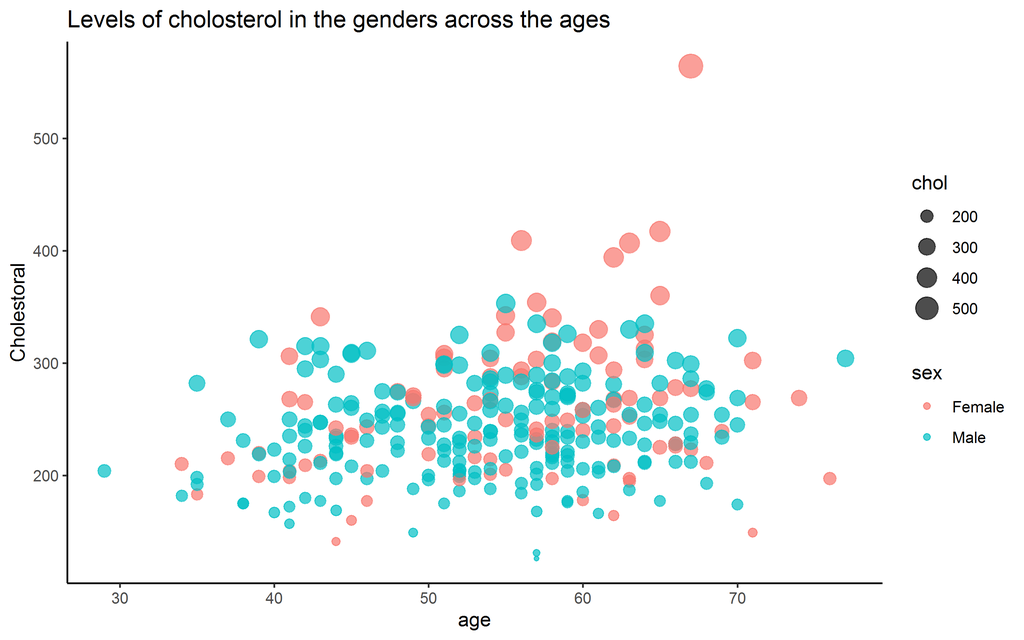

```r
heart_clean %>%
  ggplot(aes(age, chol, col = sex , size = chol )) +
  geom_point(alpha = 0.7) +
  theme_classic() +
  labs(title = "Levels of cholosterol in the genders across the ages",
       y = "Cholestoral") +
  guides(fill = guide_legend(title ="Gender"))
```

**Levels of resting blood pressure in the genders across the ages**

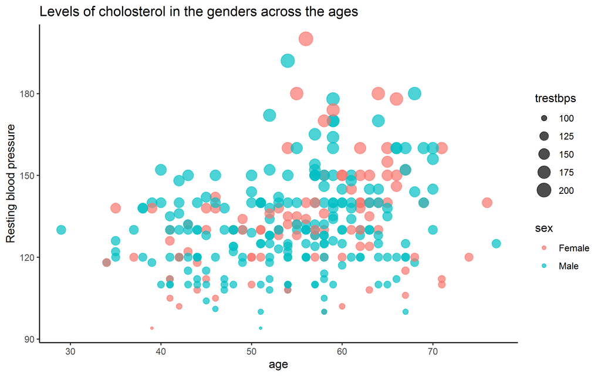

```r
heart_clean %>%
  ggplot(aes(age, trestbps, col = sex , size = trestbps )) +
  geom_point(alpha = 0.7) +
  theme_classic() +
  labs(title = "Levels of cholosterol in the genders across the ages",
       y = "Resting blood pressure") +
  guides(fill = guide_legend(title ="Gender"))
```

**Levels of maximum heart rate achieved in the genders across the ages**

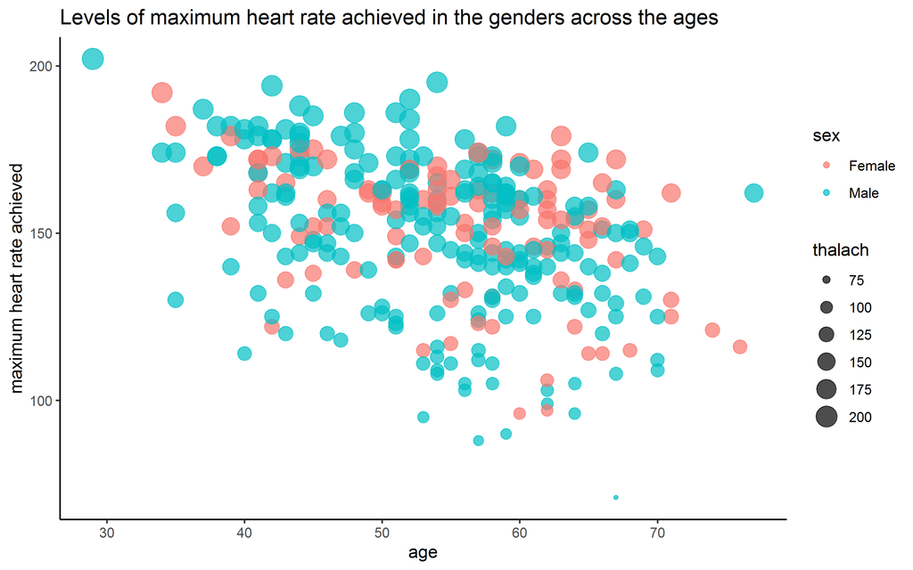

```r
heart_clean %>%
  ggplot(aes(age, thalach, col = sex , size = thalach )) +
  geom_point(alpha = 0.7) +
  theme_classic() +
  labs(title = "Levels of maximum heart rate achieved in the genders across the ages",
       y = "maximum heart rate achieved") +
  guides(fill = guide_legend(title ="Gender"))
```

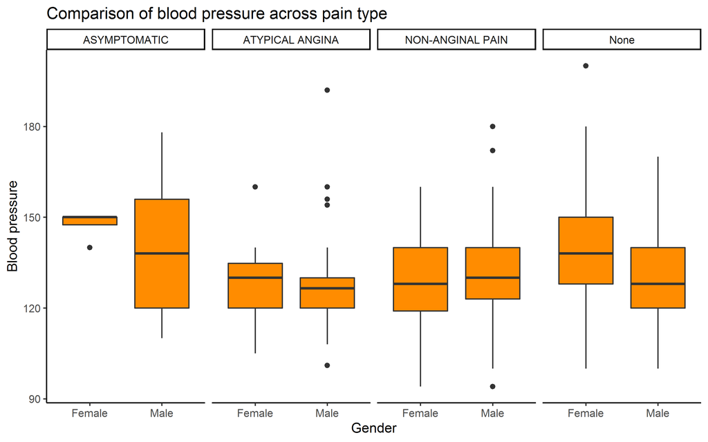

```r
heart_clean %>%
  ggplot(aes(sex, trestbps )) +
  geom_boxplot(fill = "darkorange") +
  theme_classic() +
  labs(title = "Comparison of blood pressure across pain type",
       y = "Blood pressure",
       x = "Gender") +
 facet_grid(~cp)
```

Blood pressure is highest in the "Asymptomatic" chest pain and lowest in the "Atypical angina".

Females tend to generally have a higher blood pressure compared to males.

**comparison of Pain types across ages**

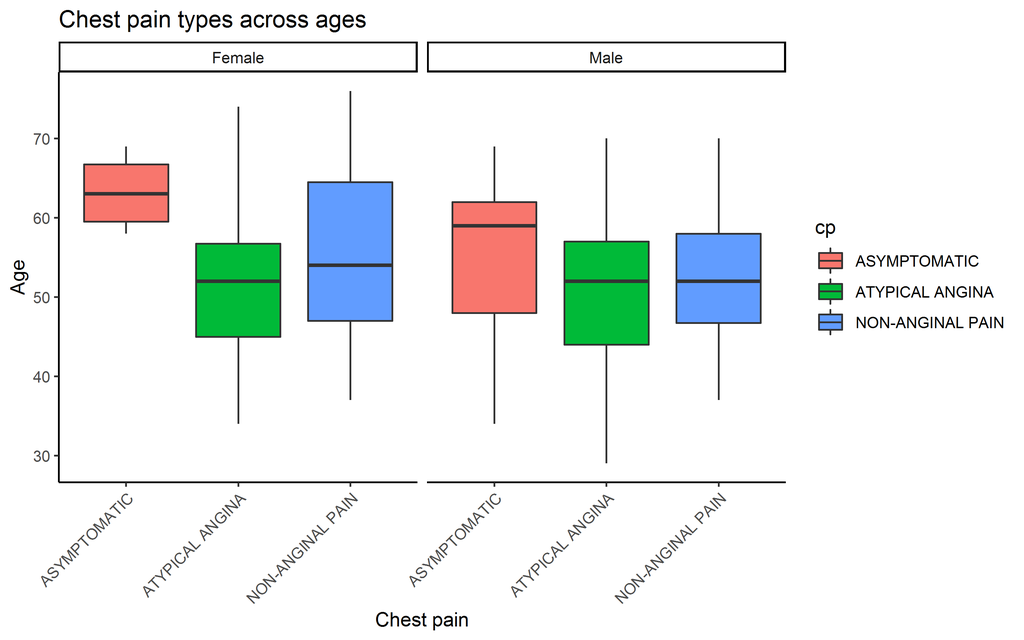

```r
heart_clean %>%
  filter(cp != "None") %>%
  ggplot(aes(cp, age, fill = cp )) +
  geom_boxplot() +
  theme_classic() +
  labs(title = "Chest pain types across ages",
       y = "Age",
       x = "Chest pain") +
  theme(axis.text.x = element_text(angle = 45, hjust = 1)) +
  facet_grid(~sex)
```

The older you are the more server the chest pain.

**Fasting blood sugar across ages**

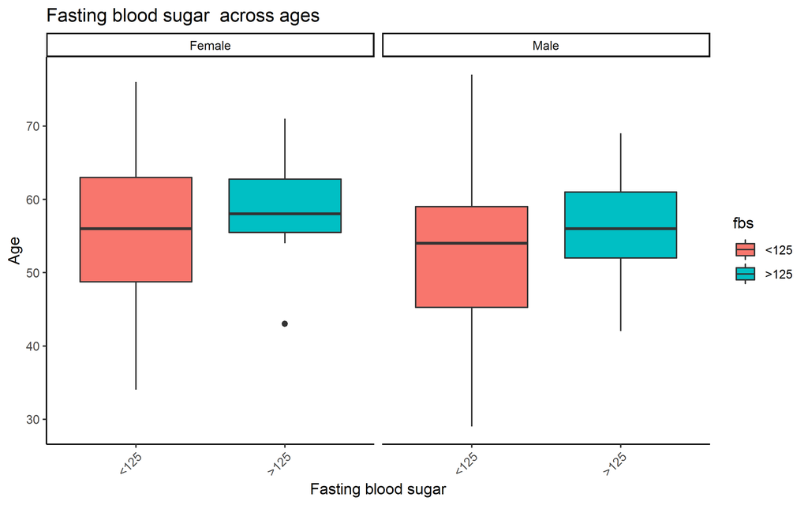

```r
heart_clean %>%
  ggplot(aes(fbs, age, fill = fbs )) +
  geom_boxplot() +
  theme_classic() +
  labs(title = "Fasting blood sugar  across ages",
       y = "Age",
       x = "Fasting blood sugar") +
  theme(axis.text.x = element_text(angle = 45, hjust = 1)) +
  facet_grid(~sex)
```

Fasting blood sugar levels are higher as you age.

**Distribution of heart disease across chest pains**

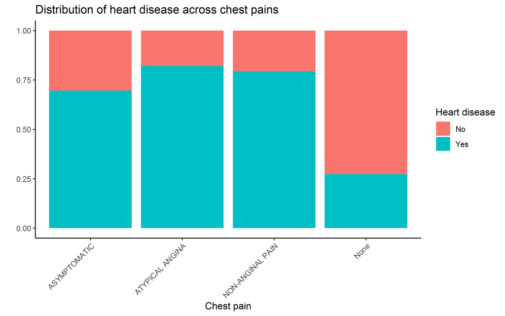

```r
heart_clean %>%
  ggplot(aes(cp, fill = target)) +
  geom_bar(position = "fill") +
  theme_classic() +
  labs(x = "Chest pain",
       y = "",
       title = "Distribution of heart disease across chest pains",
       fill = "Heart disease") +
  theme(axis.text.x = element_text(angle = 45, hjust = 1))
```

**Distribution of heart disease across resting electrocardiographic**

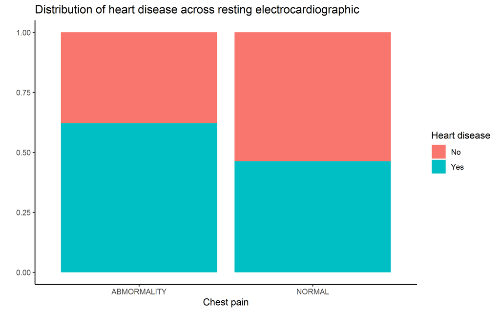

```r
heart_clean %>%
  ggplot(aes(restecg, fill = target)) +
  geom_bar(position = "fill") +
  theme_classic() +
  labs(x = "Chest pain",
       y = "",
       title = "Distribution of heart disease across resting electrocardiographic",
       fill = "Heart disease")
```

**Distribution of heart disease across the slope of the peak exercise ST segment**

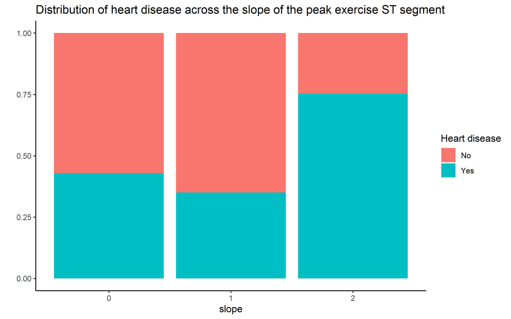

```r
heart_clean %>%
  ggplot(aes(slope, fill = target)) +
  geom_bar(position = "fill") +
  theme_classic() +
  labs(x = "slope",
       y = "",
       title = "Distribution of heart disease across the slope of the peak exercise ST segment",
       fill = "Heart disease")
```

**Distribution of heart disease across number of major vessels**

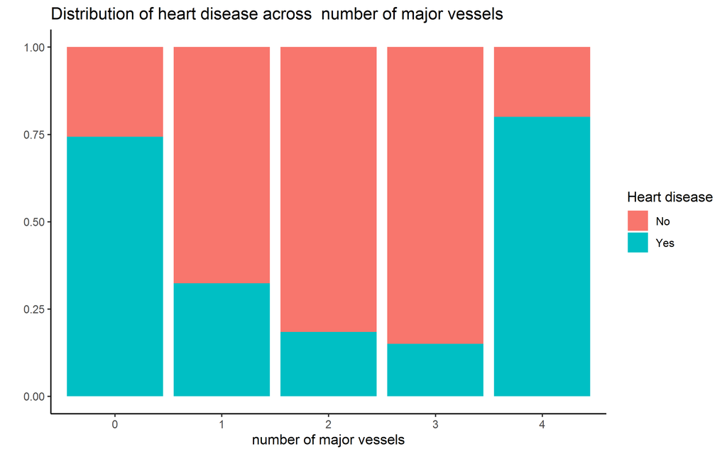

```r
heart_clean %>%
  ggplot(aes(ca, fill = target)) +
  geom_bar(position = "fill") +
  theme_classic() +
  labs(x = "number of major vessels",
       y = "",
       title = "Distribution of heart disease across  number of major vessels",
       fill = "Heart disease")
```

**Distribution of heart disease across thal**

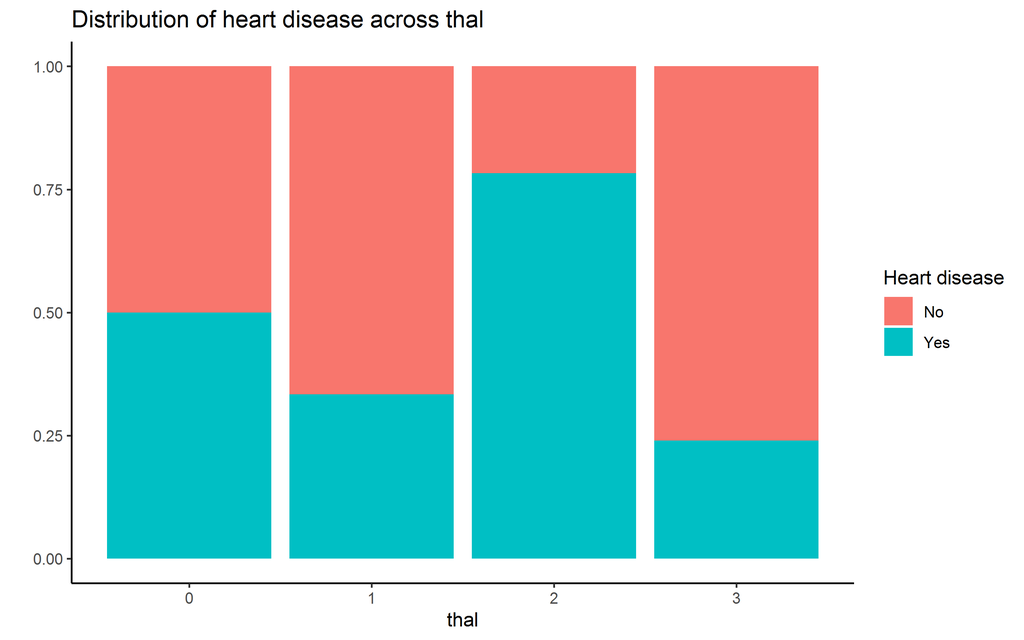

```r
heart_clean %>%
  ggplot(aes(thal, fill = target)) +
  geom_bar(position = "fill") +
  theme_classic() +
  labs(x = "thal",
       y = "",
       title = "Distribution of heart disease across thal",
       fill = "Heart disease")
```

## Correlation

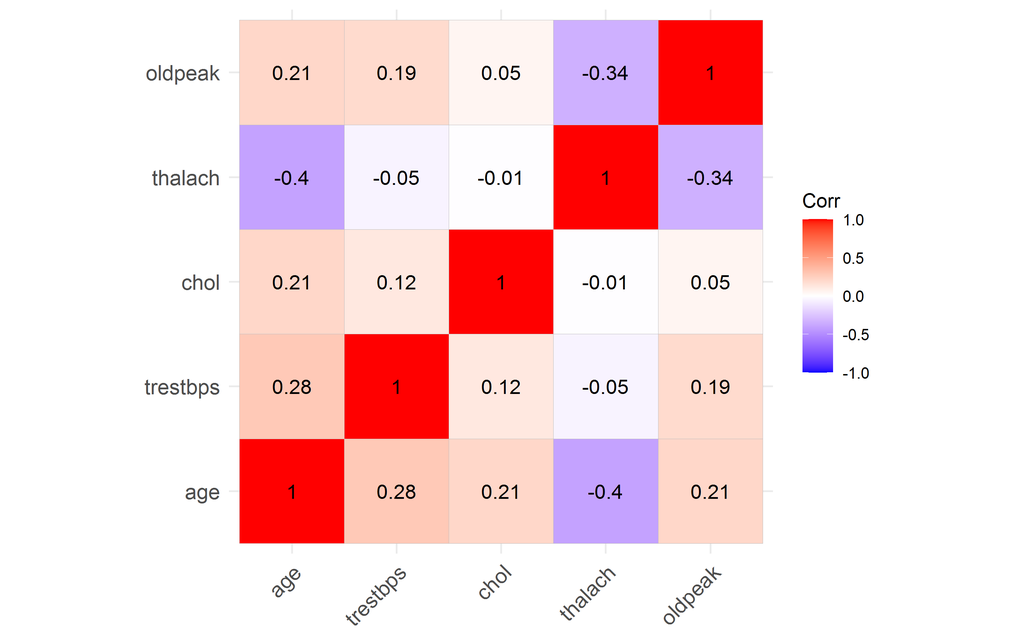

```r
cor_heart <- cor(heart[, c(1,4,5,8,10)])

col <- colorRampPalette(c("orange", "green", "blue"))(20)

ggcorrplot(cor_heart, lab = T)
```

There is no high correlation between the other variables so we don't have to worry about multicollinearity.

## MODEL BUILDING

```r
#split the data into train and test
set.seed(123)
heart_split <- initial_split(heart_clean , strata = target)
heart_train <- training(heart_split)
heart_test <- testing(heart_split)

#create folds for resampling
set.seed(345)
heart_folds <- vfold_cv(heart_train)
heart_folds
```

| splits | id |
| --- | --- |
|  | Fold01 |
|  | Fold02 |
|  | Fold03 |
|  | Fold04 |
|  | Fold05 |
|  | Fold06 |
|  | Fold07 |
|  | Fold08 |
|  | Fold09 |
|  | Fold10 |

```r
#Create a recipe
library(themis)

#The recipe helps us with class imbalances
heart_rec <- recipe(target ~ ., data = heart_train) %>%
  step_dummy(all_nominal(), -target) %>%
  step_smote(target)

#create a workflow
heart_wf <- workflow() %>%
  add_recipe(heart_rec)

heart_wf
```

```
## == Workflow ====================================================================
## Preprocessor: Recipe
## Model: None
##
## -- Preprocessor ----------------------------------------------------------------
## 2 Recipe Steps
##
## * step_dummy()
## * step_smote()
```

Build the models.

We are training a linear regression and a random forest model.

```r
#linear regression
glm_spec <- logistic_reg() %>%
  set_engine("glm")

#random forest
rf_spec <- rand_forest(trees = 1000) %>%
  set_engine("ranger") %>%
  set_mode("classification")
```

Training the linear regression model.

```r
doParallel::registerDoParallel()

set.seed(567)

glm_rs <- heart_wf %>%
  add_model(glm_spec) %>%
  fit_resamples(
    resamples = heart_folds,
    metrics = metric_set(roc_auc, accuracy, sensitivity, specificity),
    control = control_resamples(save_pred = TRUE)
  )

glm_rs
```

| splits | id | .metrics | .notes | .predictions |
| --- | --- | --- | --- | --- |
|  | Fold01 |  |  |  |
|  | Fold02 |  |  |  |
|  | Fold03 |  |  |  |
|  | Fold04 |  |  |  |
|  | Fold05 |  |  |  |
|  | Fold06 |  |  |  |
|  | Fold07 |  |  |  |
|  | Fold08 |  |  |  |
|  | Fold09 |  |  |  |
|  | Fold10 |  |  |  |

Training the random forest model.

```r
doParallel::registerDoParallel()

set.seed(678)

rf_rs <- heart_wf %>%
  add_model(rf_spec) %>%
  fit_resamples(
    resamples = heart_folds,
    metrics = metric_set(roc_auc, accuracy, sensitivity, specificity),
    control = control_resamples(save_pred = TRUE)
  )

rf_rs
```

| splits | id | .metrics | .notes | .predictions |
| --- | --- | --- | --- | --- |
|  | Fold01 |  |  |  |
|  | Fold02 |  |  |  |
|  | Fold03 |  |  |  |
|  | Fold04 |  |  |  |
|  | Fold05 |  |  |  |
|  | Fold06 |  |  |  |
|  | Fold07 |  |  |  |
|  | Fold08 |  |  |  |
|  | Fold09 |  |  |  |
|  | Fold10 |  |  |  |

## EVALUATE THE MODELS

```r
#Collect the metrics
collect_metrics(glm_rs)
```

| .metric | .estimator | mean | n | std_err | .config |
| --- | --- | --- | --- | --- | --- |
| accuracy | binary | 0.8290514 | 10 | 0.02666357 | Preprocessor1_Model1 |
| roc_auc | binary | 0.9040797 | 10 | 0.02178033 | Preprocessor1_Model1 |
| sens | binary | 0.8266234 | 10 | 0.04040998 | Preprocessor1_Model1 |
| spec | binary | 0.8199453 | 10 | 0.04445426 | Preprocessor1_Model1 |

```r
collect_metrics(rf_rs)
```

| .metric | .estimator | mean | n | std_err | .config |
| --- | --- | --- | --- | --- | --- |
| accuracy | binary | 0.8247036 | 10 | 0.02037704 | Preprocessor1_Model1 |
| roc_auc | binary | 0.8953723 | 10 | 0.02137025 | Preprocessor1_Model1 |
| sens | binary | 0.8007565 | 10 | 0.03778520 | Preprocessor1_Model1 |
| spec | binary | 0.8394245 | 10 | 0.03196666 | Preprocessor1_Model1 |

```r
#confusion matrix
glm_rs %>%
  conf_mat_resampled()
```

| Prediction | Truth | Freq |
| --- | --- | --- |
| No | No | 8.7 |
| No | Yes | 2.2 |
| Yes | No | 1.7 |
| Yes | Yes | 10.2 |

```r
rf_rs %>%
  conf_mat_resampled()
```

| Prediction | Truth | Freq |
| --- | --- | --- |
| No | No | 8.4 |
| No | Yes | 2.0 |
| Yes | No | 2.0 |
| Yes | Yes | 10.4 |

The linear regression performed better.

We will use it for our finalprediction

```r
#Tune model with best parameters
best_auc <- select_best(glm_rs, "roc_auc")

#create workflow for glm
glm_wf <- workflow() %>%
  add_model(glm_spec) %>%
  add_recipe(heart_rec)

final_glm <- finalize_workflow(glm_wf, best_auc)

final_results <- glm_wf %>% last_fit(heart_split)

collect_metrics(final_results)
```

| .metric | .estimator | .estimate | .config |
| --- | --- | --- | --- |
| accuracy | binary | 0.7733333 | Preprocessor1_Model1 |
| roc_auc | binary | 0.8744620 | Preprocessor1_Model1 |

Let us look at variable imporatnce charts.

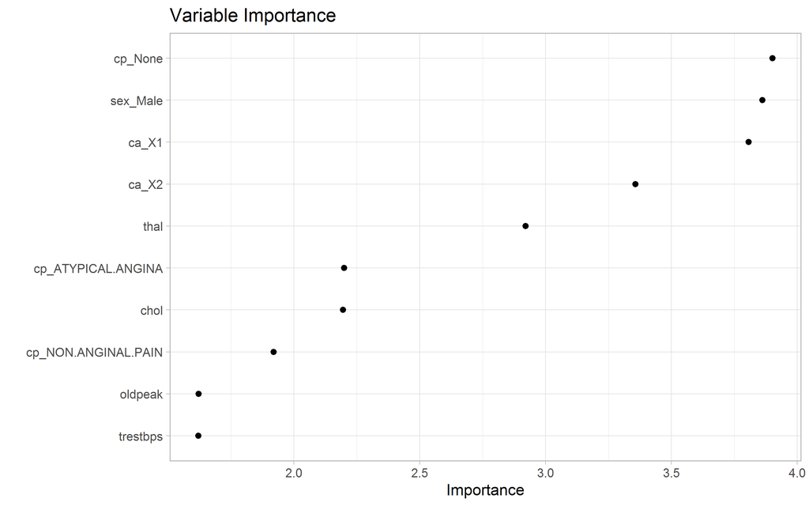

```r
final_glm %>%
  fit(data = heart_train) %>%
  pull_workflow_fit() %>%
  vip(geom = "point") +
  theme_light() +
  ggtitle("Variable Importance")
```